# DA5020.A7.Yicheng.Zhang

YICHENG ZHANG

2022-10-26

```r
library(httr)
library(ggplot2)
library(rvest)
library(dplyr)
library(tidyverse)
```

# Question 1.

# 1.

```r
wikiurl <- read_html("https://en.wikipedia.org/wiki/List_of_countries_by_percentage_of_population_living_in_poverty")
Webpage <- wikiurl %>%
  html_table(., fill = T)
poverty <- Webpage[[2]]
povertyData <- poverty %>%
  rename(
    less_than_1.90 = "< $1.90[1][5]",
    less_than_3.20 = "< $3.20[6]",
    less_than_5.50 = "< $5.50[7]"
    )
povertyData <- povertyData %>% mutate('less_than_1.90' = as.numeric(sub("%", "", povertyData$less_than_1.90, fixed = TRUE))/100,
                                        'less_than_3.20' = as.numeric(sub("%", "", povertyData$less_than_3.20, fixed = TRUE))/100,
                                        'less_than_5.50' = as.numeric(sub("%", "", povertyData$less_than_5.50, fixed = TRUE))/100,
                                        'Year' = as.numeric(povertyData$Year))
# check loaded table:

str(povertyData)
```

```
## tibble [167 × 6] (S3: tbl_df/tbl/data.frame)
##  $ Country       : chr [1:167] "Albania" "Algeria" "Angola" "Argentina" ...
##  $ less_than_1.90: num [1:167] 0.1 0.0032 0.514 0.016 0.004 0.005 0.006 0 0.0662 0 ...
##  $ less_than_3.20: num [1:167] 0.266 0.0223 0.7279 0.058 0.069 ...
##  $ less_than_5.50: num [1:167] 0.384 0.208 0.891 0.182 0.447 ...
##  $ Year          : num [1:167] 2019 2019 2019 2020 2020 ...
##  $ Continent     : chr [1:167] "Europe" "Africa" "Africa" "South America" ...
```

# 2.

```r
tableq2<-povertyData %>%
    group_by(Continent) %>%
    summarise( mean_5.50= mean(less_than_5.50),
               sd_5.50 = sd(less_than_5.50)  ) %>%
    arrange(mean_5.50)

# table view of our result:
tableq2
```

```
## # A tibble: 7 × 3
##   Continent     mean_5.50 sd_5.50
##   <chr>             <dbl>   <dbl>
## 1 Europe           0.0491  0.0914
## 2 Asia, Europe     0.0673  0.0490
## 3 South America    0.217   0.123
## 4 North America    0.285   0.207
## 5 Asia             0.349   0.302
## 6 Oceania          0.492   0.274
## 7 Africa           0.743   0.254
```

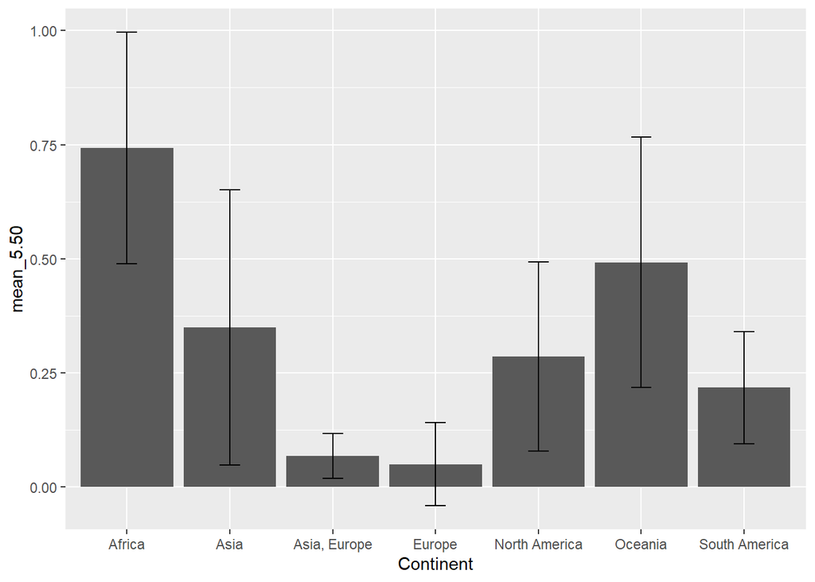

```r
# visualization
visual2<-ggplot(tableq2,aes(x = Continent, y = mean_5.50)) +
        geom_bar(stat = 'identity') +
        geom_errorbar(aes(ymin=mean_5.50-sd_5.50, ymax=mean_5.50+sd_5.50), width=.2,
                      position = position_dodge(0.9))

visual2
```

# 3.

```r
tableq3<-povertyData %>%
  select(Country,less_than_5.50,Continent,Year)%>%
    arrange(desc(less_than_5.50)) %>%
    top_n(10,less_than_5.50)

# table view of the result
tableq3
```

```
## # A tibble: 10 × 4
##    Country                           less_than_5.50 Continent  Year
##    <chr>                                      <dbl> <chr>     <dbl>
##  1 South Sudan                                0.984 Africa     2019
##  2 Burundi                                    0.980 Africa     2019
##  3 Somalia                                    0.979 Africa     2019
##  4 Malawi                                     0.971 Africa     2019
##  5 Madagascar                                 0.971 Africa     2019
##  6 Congo, Democratic Republic of the          0.968 Africa     2019
##  7 Yemen                                      0.946 Asia       2019
##  8 Liberia                                    0.945 Africa     2019
##  9 Central African Republic                   0.943 Africa     2019
## 10 Mali                                       0.933 Africa     2019
```

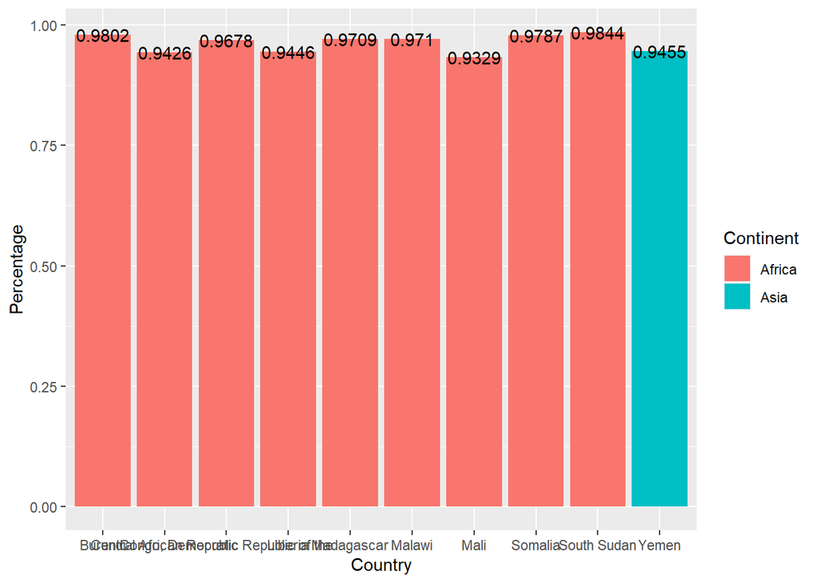

```r
# visualization
visual3<-ggplot(tableq3,aes(x = Country, y = less_than_5.50, fill = Continent)) +
        geom_bar(stat = 'identity') +
        labs( y = "Percentage",
              x = "Country") +
        geom_text(aes(label = less_than_5.50))

visual3
```

From the result above we can see that the South sudan has most population living under 5 dollar per day (98.44%). 9 of these countries from Africa and only Yemen from Asia. Mali has the lowest percent among these 10 countries but it is still very high (93.29). We should definitely take some actions in Africa to help solve the sever poverty condition there and this result just reminds us to do so.

# 4.

```r
tableq4<-povertyData %>%
    arrange((less_than_5.50))%>%
  select(Country,less_than_5.50,Year, Continent)

# table view of the result:
tableq4<-head(tableq4,5)
tableq4
```

```
## # A tibble: 5 × 4
##   Country              less_than_5.50  Year Continent
##   <chr>                         <dbl> <dbl> <chr>
## 1 Azerbaijan                   0       2019 Asia
## 2 United Arab Emirates         0       2019 Asia
## 3 Iceland                      0.0004  2019 Europe
## 4 Belarus                      0.001   2020 Europe
## 5 Finland                      0.001   2019 Europe
```

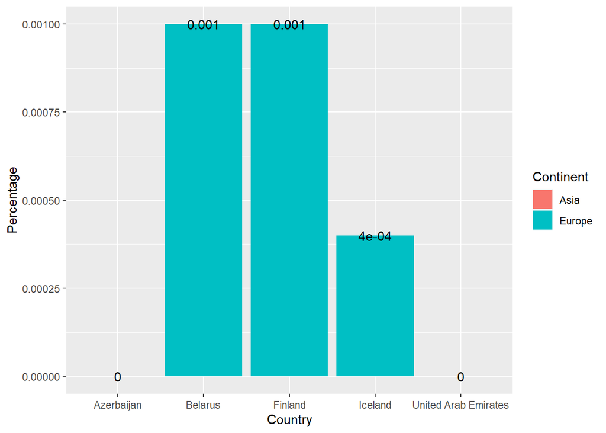

```r
# visualization
visual4<-ggplot(tableq4, aes(x = Country, y = less_than_5.50, fill = Continent)) +
        geom_bar(stat = 'identity') +
        labs( y = "Percentage",
              x = "Country") +
        geom_text(aes(label = less_than_5.50))

visual4
```

From the result above there are 5 countries with the least population have live less than 5 dollar each day in the world and they are from Europe and Asia: Belarus, Finland, Iceland, Azerbaijan and United Arab Emirates. The highest percentage for people living under 5 dollar per day among these countries is Belarus and Finland which is 0.1%. Azerbaijan and United Arab Emirates from countries from Asia and they even have zero percent of people who live less than 5 dollar per day which is incredible. If the data we got from Wikipedia is correct, then those are probably the richest countries in the world. We can then find the lowest percentage of population having a income of less than 1.90 and 3.20 dollar per day:

```r
tableq4.1<-povertyData %>%
    arrange((less_than_3.20))%>%
  select(Country,less_than_3.20,Year, Continent)

# table view of the result:
tableq4.1<-head(tableq4.1,5)
tableq4.1
```

```
## # A tibble: 5 × 4
##   Country        less_than_3.20  Year Continent
##   <chr>                   <dbl> <dbl> <chr>
## 1 Azerbaijan                  0  2019 Asia
## 2 Belarus                     0  2020 Europe
## 3 Czech Republic              0  2019 Europe
## 4 Iceland                     0  2019 Europe
## 5 Maldives                    0  2019 Asia
```

```r
tableq4.2<-povertyData %>%
    arrange((less_than_1.90))%>%
  select(Country,less_than_1.90,Year, Continent)

# table view of the result:
tableq4.2<-head(tableq4.2,5)
tableq4.2
```

```
## # A tibble: 5 × 4
##   Country        less_than_1.90  Year Continent
##   <chr>                   <dbl> <dbl> <chr>
## 1 Azerbaijan                  0  2019 Asia
## 2 Belarus                     0  2020 Europe
## 3 Czech Republic              0  2019 Europe
## 4 Finland                     0  2019 Europe
## 5 Germany                     0  2019 Europe
```

By finding the lowest percentage of population having a income of less than 1.90 and 3.20 dollar per day, we can see that there are 2 countries from Asia ans 3 countries from Europe have least people living less than 3.20 dollar per day; 1 country from Asia, 4 countries from Europe have least people living less than 1.90 dollar per day; Again, this result indicates the income inequality of different regions in the world, and most of the rich countries are from Europe and the poverty situation there is basically gone. For the Asia it also has some of countries without the concern about poverty but from the result we got in previous questions, we know that Asia is definitely not a place without poverty but rather, this result, further proved that Asia is a very unbalanced continent. Since the results of all these 3 standards are only from two continents, we say the global poverty and income inequality is still a big problem we need to face.

# 5.

```r
tableq5<-povertyData %>%
  filter( Continent == c("Africa", "Oceania")) %>%
  pivot_longer( c(less_than_1.90,less_than_3.20,less_than_5.50), names_to = "value", values_to = "percentage")
# table view of the result:
head(tableq5)
```

```
## # A tibble: 6 × 5
##   Country    Year Continent value          percentage
##   <chr>     <dbl> <chr>     <chr>               <dbl>
## 1 Angola     2019 Africa    less_than_1.90     0.514
## 2 Angola     2019 Africa    less_than_3.20     0.728
## 3 Angola     2019 Africa    less_than_5.50     0.891
## 4 Australia  2019 Oceania   less_than_1.90     0.005
## 5 Australia  2019 Oceania   less_than_3.20     0.0074
## 6 Australia  2019 Oceania   less_than_5.50     0.0074
```

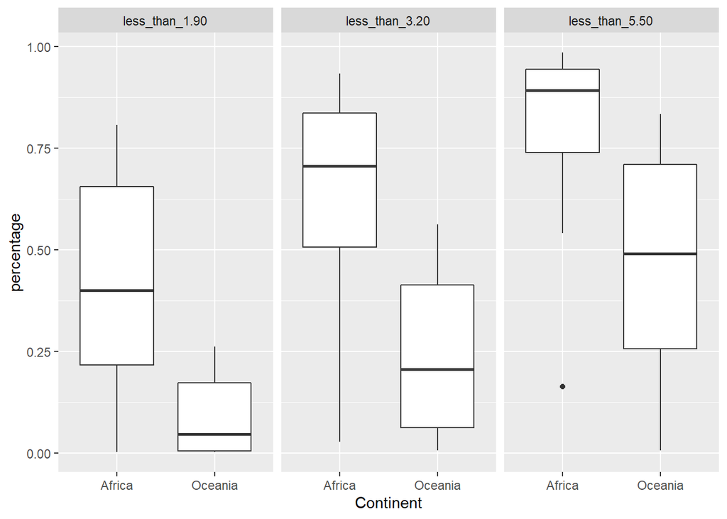

```r
# visualization:
visual5<-ggplot(tableq5) +
    geom_boxplot( mapping = aes( x = Continent, y = percentage )) +
    facet_wrap(vars(value))

visual5
```

For the `less_than_1.90`, region from Africa is left skewed and Oceania has skewness to the right;for `less_than_3.20` the skewness of the Africa is left and for the Oceania it is right skewed, for `less_than_$5.50` Africa is left skewed and Oceania is left skewed as well. In general the countries from Africa have a higher median value than Oceanian countries. In the `less_than_1.90`, the Oceania has less 25 percent quantile. For the `less_than_3.20` and `less_than_$5.50`, the Oceania has larger 5 percentage quantile. In this case the We can see there are outliers exits for Africa from `less_than_$5.50` group.

```r
africa<-povertyData %>%
 filter( Continent == 'Africa') %>%
 arrange(desc(less_than_5.50))

data1<-africa[,1:6]

q <- quantile(data1$less_than_5.50, probs=c(.25, .75), na.rm = FALSE)
Interq <- IQR(data1$less_than_5.50)

Lower_boundary <- q[1] - 1.5*Interq
Upper_boundary <- q[2] + 1.5*Interq

# find outliers:

outlier <-data1%>%filter(less_than_5.50<Lower_boundary | less_than_5.50> Upper_boundary)
outlier
```

```
## # A tibble: 4 × 6
##   Country    less_than_1.90 less_than_3.20 less_than_5.50  Year Continent
##   <chr>               <dbl>          <dbl>          <dbl> <dbl> <chr>
## 1 Algeria            0.0032         0.0223         0.208   2019 Africa
## 2 Tunisia            0.0022         0.0284         0.164   2019 Africa
## 3 Mauritius          0.0013         0.0179         0.103   2019 Africa
## 4 Seychelles         0.004          0.0097         0.0476  2019 Africa
```

We use the quantile() to get the first and third quartiles. Furthermore, we compute first quantile - 1.5IQR to get the lower limit for outliers, and similarly, we compute third quantile + 1.5IQR to get the upper bound. With such method, we have these 4 outliers countries in the `less_than_5.50` from Africa: Algeria, Tunisia, Mauritius and Seychelles.